# Red Wine Quality Analysis by Saisandeep

Loading the dataset: Below are the first few records of the dataset.

```
##   X fixed.acidity volatile.acidity citric.acid residual.sugar chlorides
## 1 1           7.4             0.70        0.00            1.9     0.076
## 2 2           7.8             0.88        0.00            2.6     0.098
## 3 3           7.8             0.76        0.04            2.3     0.092
## 4 4          11.2             0.28        0.56            1.9     0.075
## 5 5           7.4             0.70        0.00            1.9     0.076
## 6 6           7.4             0.66        0.00            1.8     0.075
##   free.sulfur.dioxide total.sulfur.dioxide density   pH sulphates alcohol
## 1                  11                   34  0.9978 3.51      0.56     9.4
## 2                  25                   67  0.9968 3.20      0.68     9.8
## 3                  15                   54  0.9970 3.26      0.65     9.8
## 4                  17                   60  0.9980 3.16      0.58     9.8
## 5                  11                   34  0.9978 3.51      0.56     9.4
## 6                  13                   40  0.9978 3.51      0.56     9.4
##   quality
## 1       5
## 2       5
## 3       5
## 4       6
## 5       5
## 6       5
```

Below is the basic statistics on each variable and broad overview of the data.

```
##        X          fixed.acidity   volatile.acidity  citric.acid
##  Min.   :   1.0   Min.   : 4.60   Min.   :0.1200   Min.   :0.000
##  1st Qu.: 400.5   1st Qu.: 7.10   1st Qu.:0.3900   1st Qu.:0.090
##  Median : 800.0   Median : 7.90   Median :0.5200   Median :0.260
##  Mean   : 800.0   Mean   : 8.32   Mean   :0.5278   Mean   :0.271
##  3rd Qu.:1199.5   3rd Qu.: 9.20   3rd Qu.:0.6400   3rd Qu.:0.420
##  Max.   :1599.0   Max.   :15.90   Max.   :1.5800   Max.   :1.000
##  residual.sugar     chlorides       free.sulfur.dioxide
##  Min.   : 0.900   Min.   :0.01200   Min.   : 1.00
##  1st Qu.: 1.900   1st Qu.:0.07000   1st Qu.: 7.00
##  Median : 2.200   Median :0.07900   Median :14.00
##  Mean   : 2.539   Mean   :0.08747   Mean   :15.87
##  3rd Qu.: 2.600   3rd Qu.:0.09000   3rd Qu.:21.00
##  Max.   :15.500   Max.   :0.61100   Max.   :72.00
##  total.sulfur.dioxide    density             pH          sulphates
##  Min.   :  6.00       Min.   :0.9901   Min.   :2.740   Min.   :0.3300
##  1st Qu.: 22.00       1st Qu.:0.9956   1st Qu.:3.210   1st Qu.:0.5500
##  Median : 38.00       Median :0.9968   Median :3.310   Median :0.6200
##  Mean   : 46.47       Mean   :0.9967   Mean   :3.311   Mean   :0.6581
##  3rd Qu.: 62.00       3rd Qu.:0.9978   3rd Qu.:3.400   3rd Qu.:0.7300
##  Max.   :289.00       Max.   :1.0037   Max.   :4.010   Max.   :2.0000
##     alcohol         quality
##  Min.   : 8.40   Min.   :3.000
##  1st Qu.: 9.50   1st Qu.:5.000
##  Median :10.20   Median :6.000
##  Mean   :10.42   Mean   :5.636
##  3rd Qu.:11.10   3rd Qu.:6.000
##  Max.   :14.90   Max.   :8.000
```

Below is the data structure for all the variables and gives us a vague information on what kind of data each variable has.

```
## 'data.frame':    1599 obs. of  13 variables:
##  $ X                   : int  1 2 3 4 5 6 7 8 9 10 ...
##  $ fixed.acidity       : num  7.4 7.8 7.8 11.2 7.4 7.4 7.9 7.3 7.8 7.5 ...
##  $ volatile.acidity    : num  0.7 0.88 0.76 0.28 0.7 0.66 0.6 0.65 0.58 0.5 ...
##  $ citric.acid         : num  0 0 0.04 0.56 0 0 0.06 0 0.02 0.36 ...
##  $ residual.sugar      : num  1.9 2.6 2.3 1.9 1.9 1.8 1.6 1.2 2 6.1 ...
##  $ chlorides           : num  0.076 0.098 0.092 0.075 0.076 0.075 0.069 0.065 0.073 0.071 ...
##  $ free.sulfur.dioxide : num  11 25 15 17 11 13 15 15 9 17 ...
##  $ total.sulfur.dioxide: num  34 67 54 60 34 40 59 21 18 102 ...
##  $ density             : num  0.998 0.997 0.997 0.998 0.998 ...
##  $ pH                  : num  3.51 3.2 3.26 3.16 3.51 3.51 3.3 3.39 3.36 3.35 ...
##  $ sulphates           : num  0.56 0.68 0.65 0.58 0.56 0.56 0.46 0.47 0.57 0.8 ...
##  $ alcohol             : num  9.4 9.8 9.8 9.8 9.4 9.4 9.4 10 9.5 10.5 ...
##  $ quality             : int  5 5 5 6 5 5 5 7 7 5 ...
```

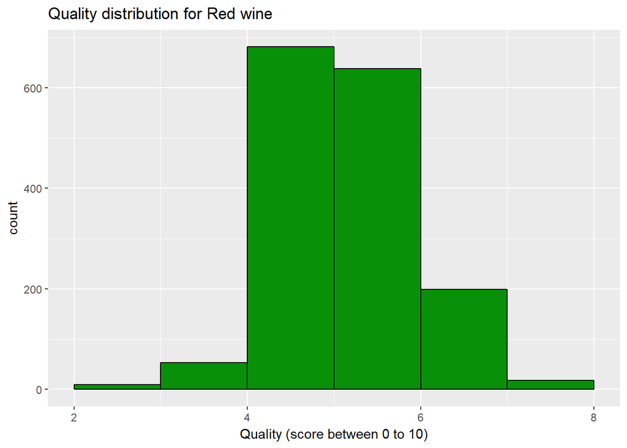

```
##
##   3   4   5   6   7   8
##  10  53 681 638 199  18
```

From the above analysis of the quality of the wines I can see that most of them have a rating of 5 or 6 and quite a few with the rating of 7. I would like to analyze what are the qulaities that tend to improve the quality of the wine.

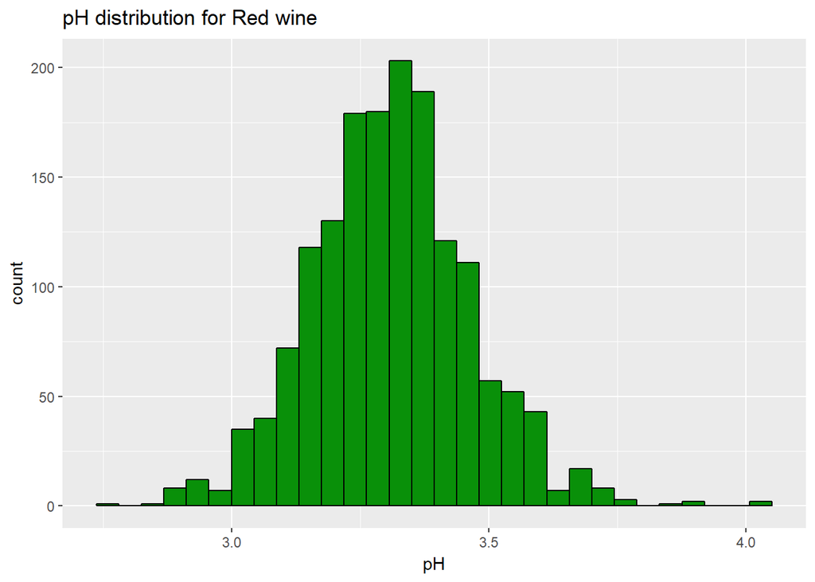

```
##    Min. 1st Qu.  Median    Mean 3rd Qu.    Max.
##   2.740   3.210   3.310   3.311   3.400   4.010
```

pH is the continuous variable with short range. Most of the wine have 3.0 to 3.7 pH value

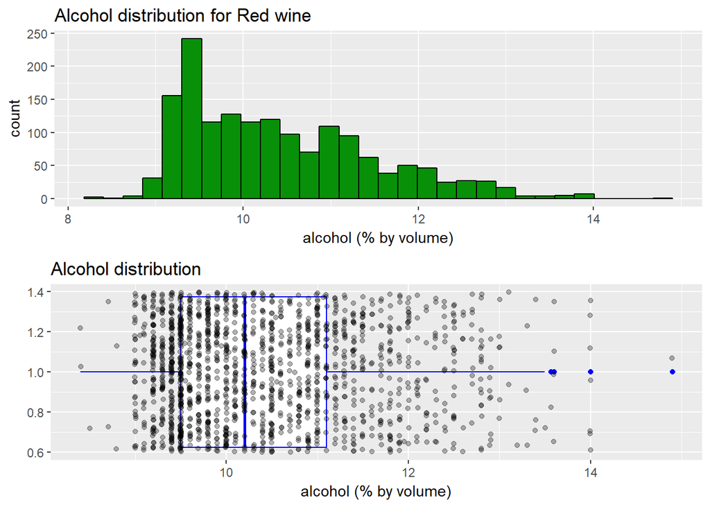

Distribution of Alcohol looks sckewed to the right and few outliers and it will be interesting to see how the quality is effected with respect to Alcohol percentage.

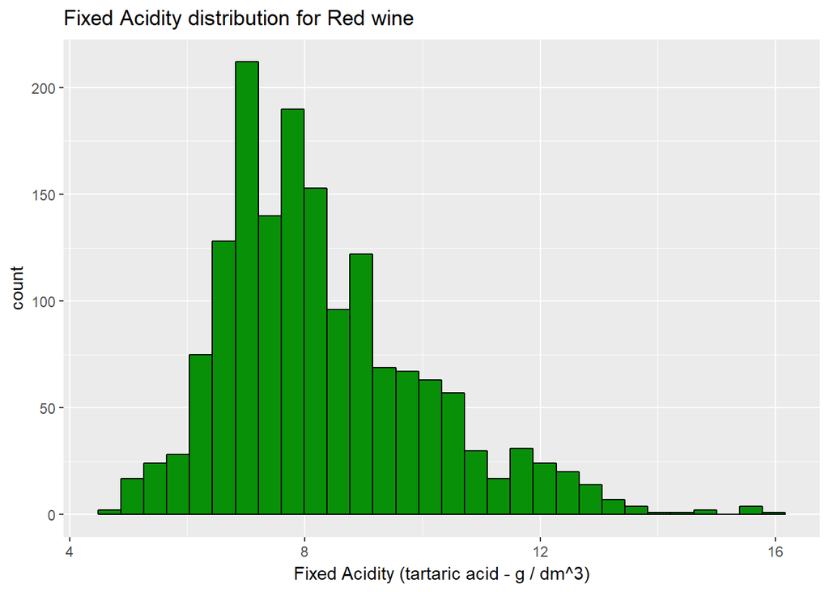

Fixed acidity looks normally distributed but has a long tail on the right side. This means there are few wine, which have high acidity.

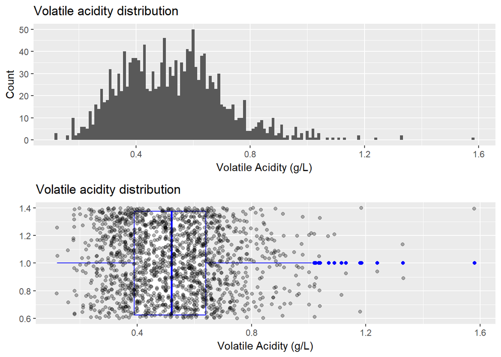

When it comes to Volatile acidity, there are outliters and some look to be really away from the rest of the wine. We need to investigate further if the acidity captured is really true. Also we need to investigate if we can drop one of records like that from the analysis.

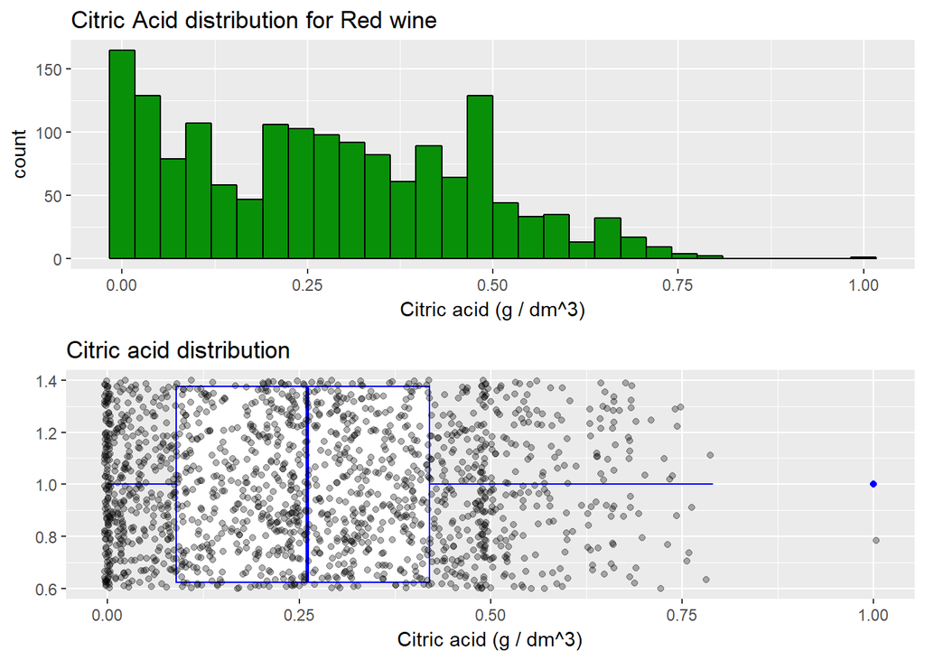

Citric acid distribution looks very spreadout, with few outliers. Also looks like there are huge number of wine with out any citric acid in them. In later stage if we see any significant affect of citric acid on quality we should be analyzing the wine with and without citric acid separately.

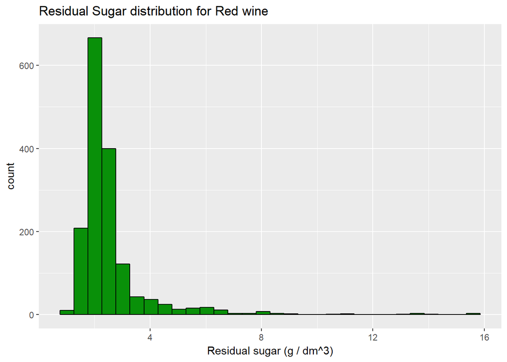

Looks like most of the wine have low residual sugar but there are few outliers with high residual sugar.

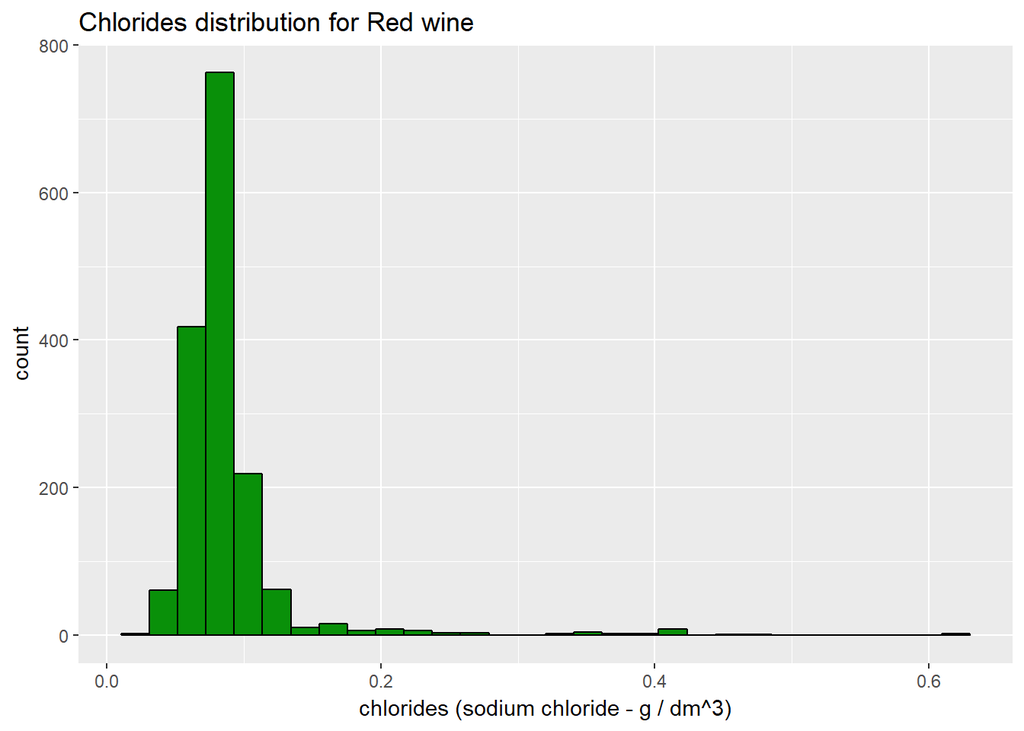

Sodium chloride concentration levels are distributed normally with a lot of sckewness and outliers.

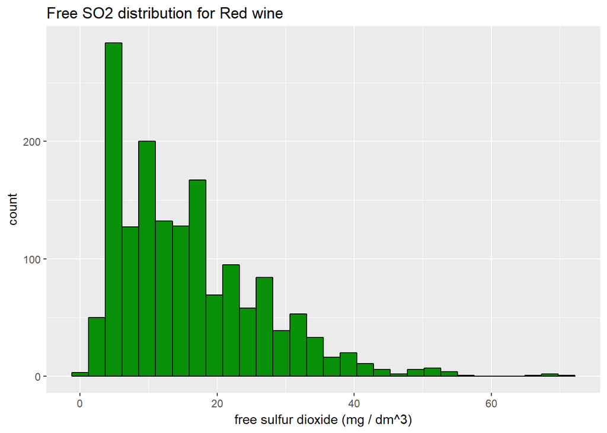

Free SO2 distribution in the wine looks to be having outliers as well and there is sckewness on the right.

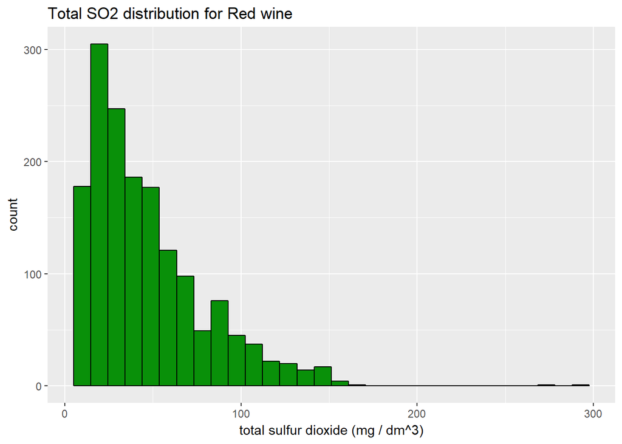

The distribution of the total sulphur dioxide is sckewed to the right as well with low values of the total SO2 in the wine.

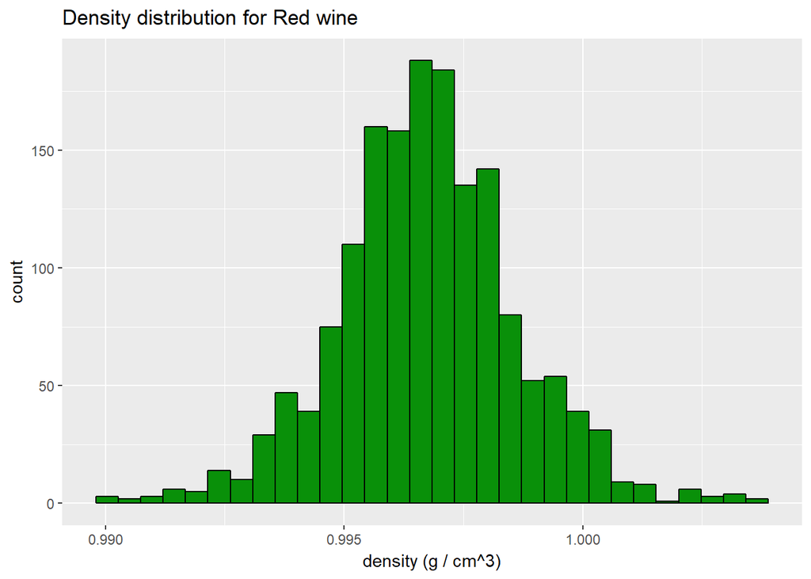

Looks like Density fo the wine is normally distributed and most of the wine having the mean density close 0.997

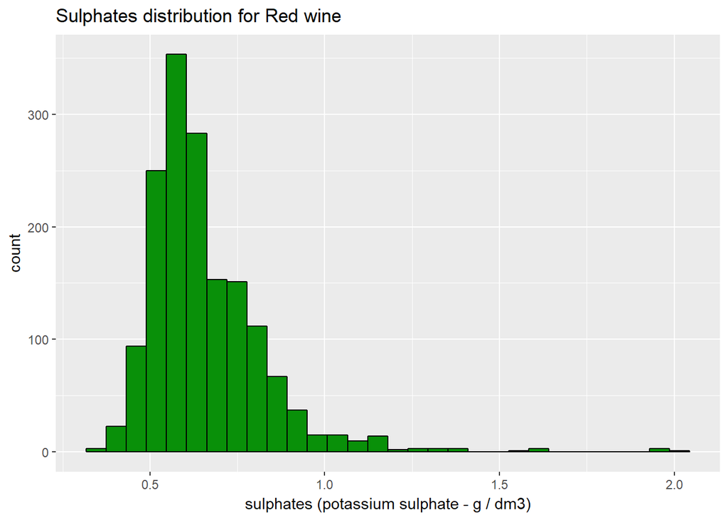

Based on the above graph the sulphate distribution seems to have few outliers.

Based on lot of studines on Wine rating, most of the places say below are 4 factors that determine the quality of the wine. Also based on the preliminary analysis below 4 factors looks intresting for further investigation.

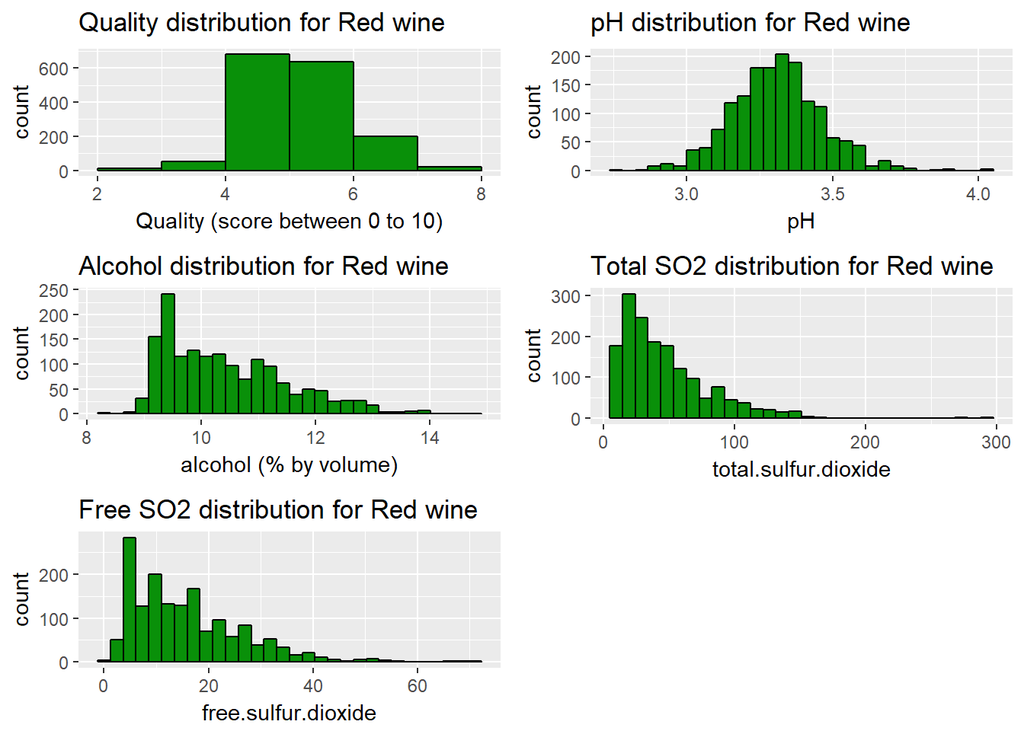

# Univariate Analysis

# Bivariate Plots Section

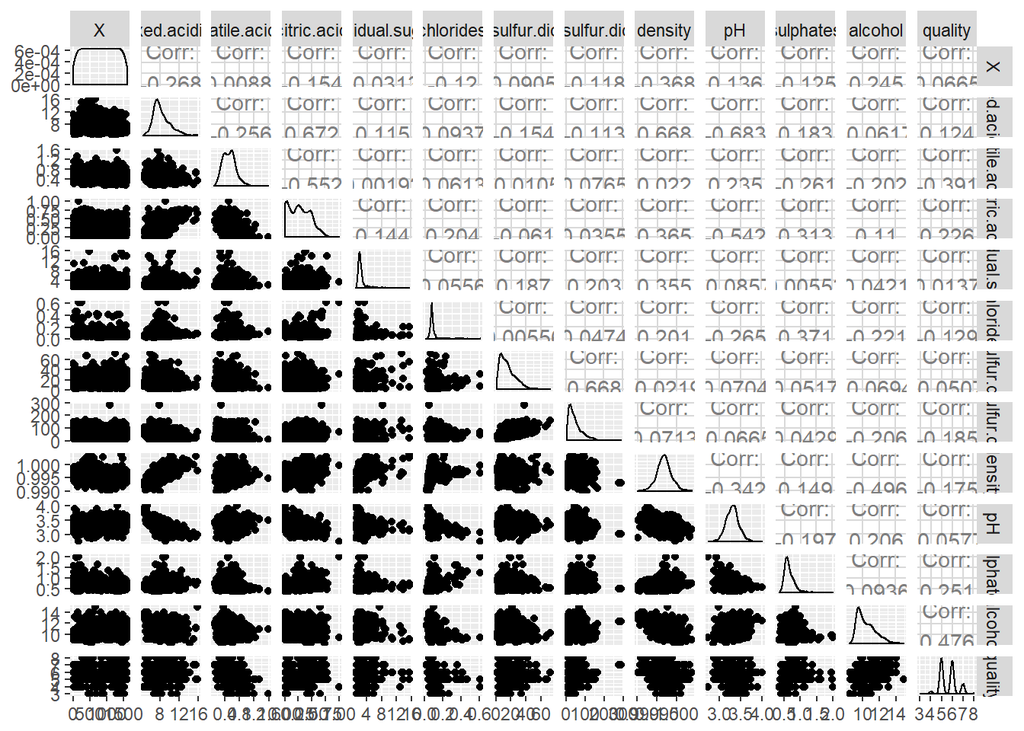

I would like to analyse how the concentration of SO2 with respect to quality.

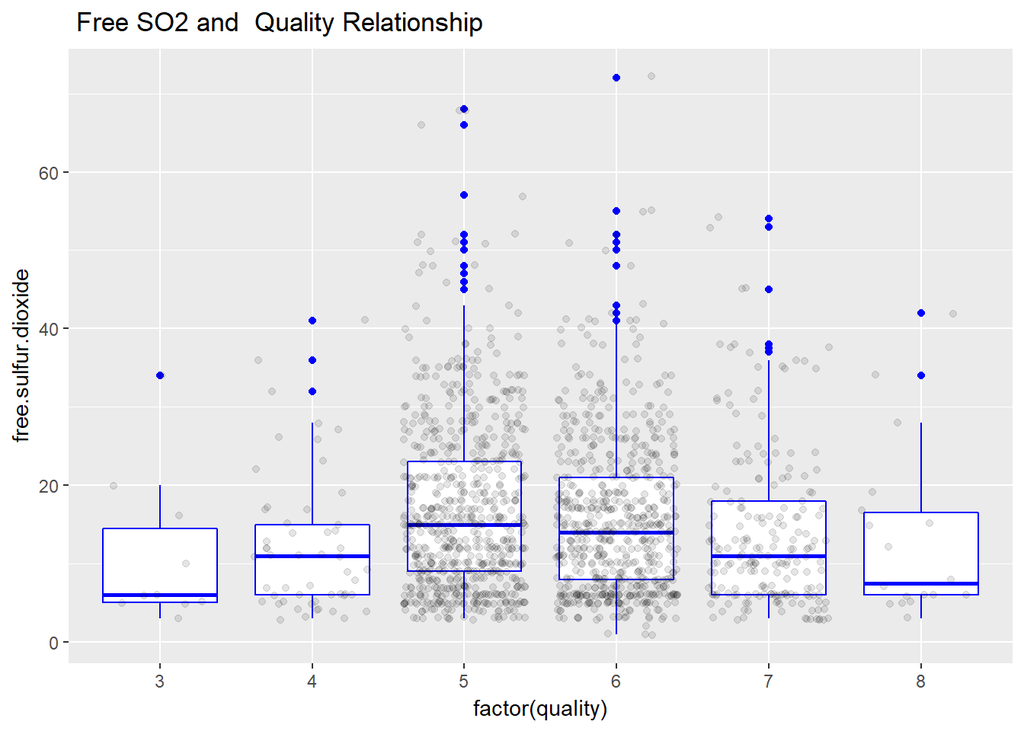

The above graph, has a boxplot of over all free SO2 and SO2 concentration for each of the quality rating. So I see that the for higher ratings mean seems to be low. Also for the lower ratings we can see low free SO2. We can infer that higher SO2 will reduce the rating but lower SO2 doesnt ensure the increase in rating.

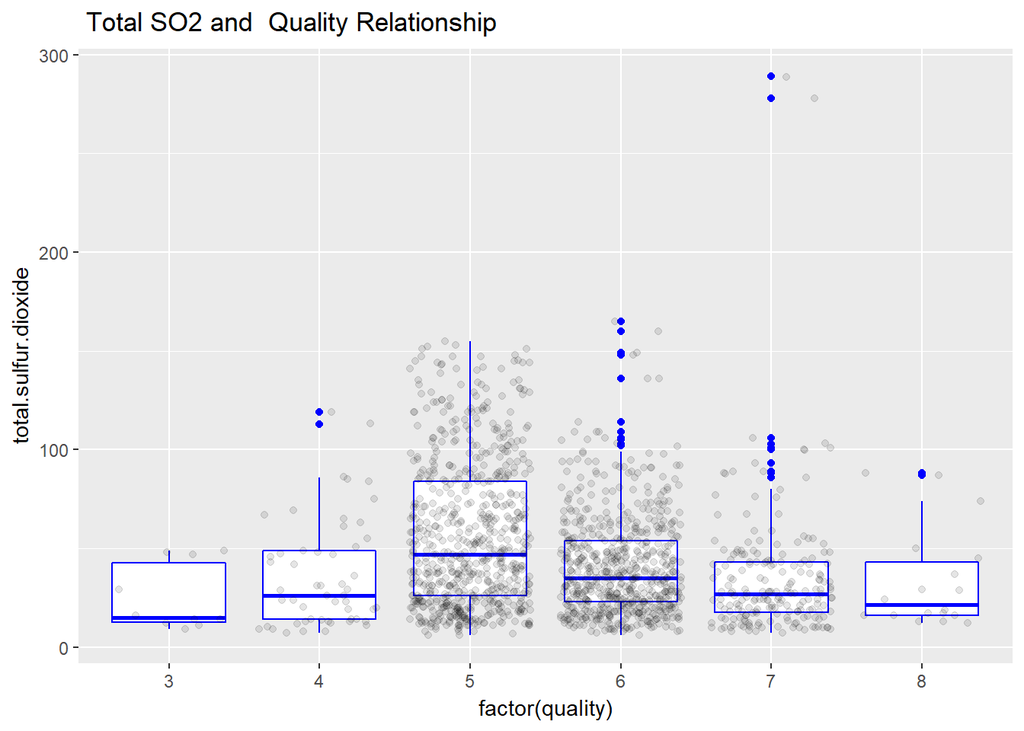

# Bivariate Analysis

### Talk about some of the relationships you observed in this part of the investigation. How did the feature(s) of interest vary with other features in the dataset?

Alcohol has positive correlation with pH and quality NEGATIVE Correlation with density, total and free so2, chlorides

Quality has positive correlation with alcohol, sulphates negative correaltion with density, chlorides, volatile acidity

### What was the strongest relationship you found?

Strongest relationship is between pH and Fixed acidicity.

# Multivariate Plots Section

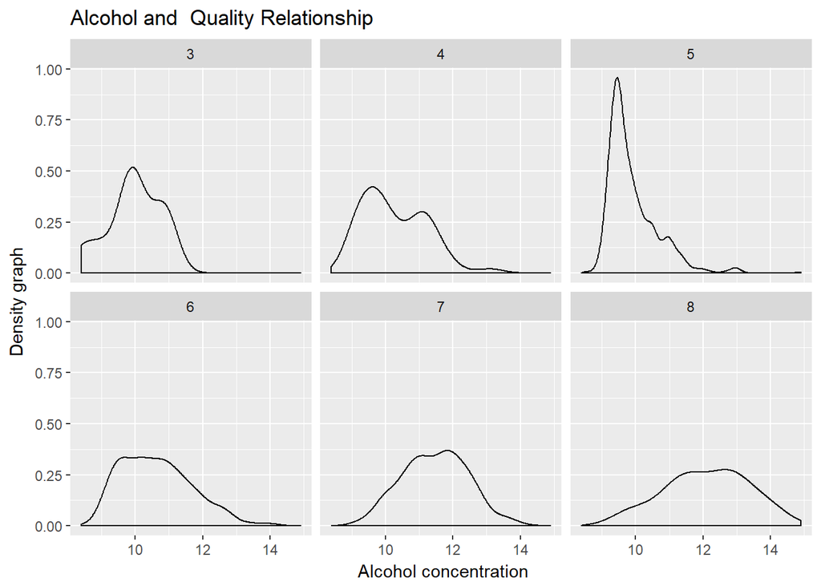

[figure not shown]

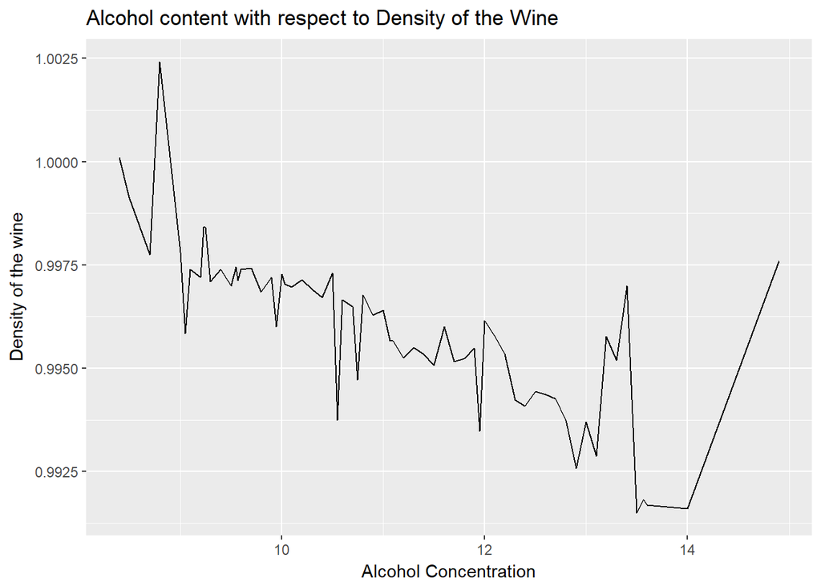

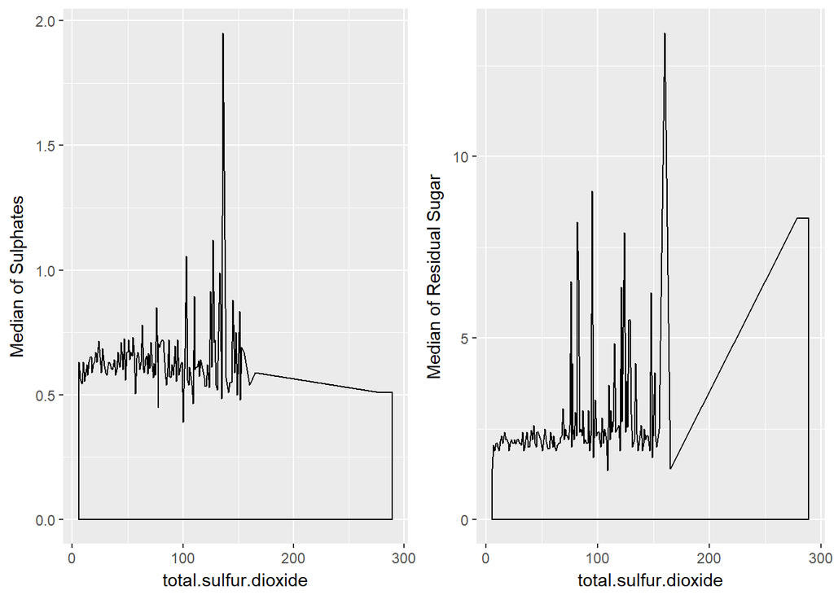

The above graphs conclude that the sulphates and residual sugar doesn’t affect much of the total SO2.

# Multivariate Analysis

### Talk about some of the relationships you observed in this part of the investigation. Were there features that strengthened each other in terms of looking at your feature(s) of interest?

The quantity of Residual sugar seems to be on higher after the 150 unit level for Total SO2

# Final Plots and Summary

### Plot One

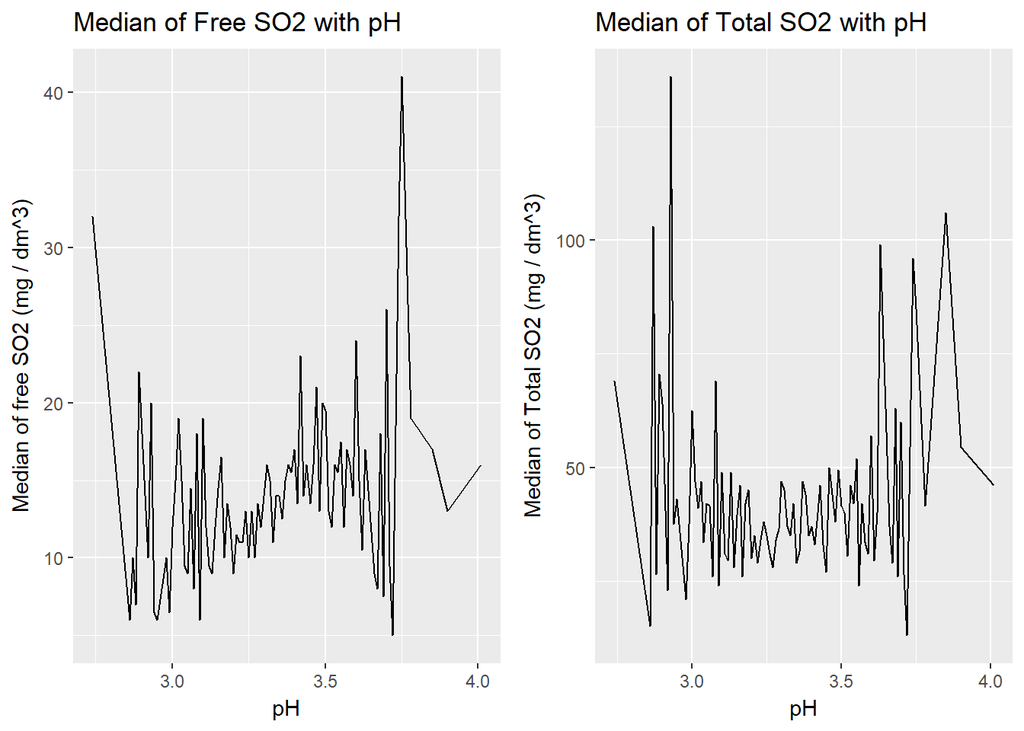

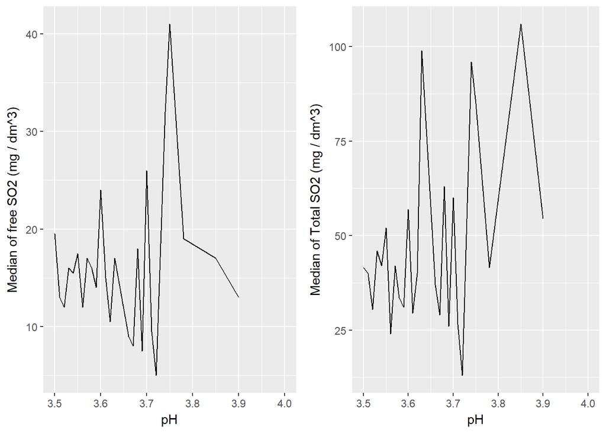

### Description One

SO2 content seems to increase with pH and I sepcifically explored tail of the above graph to see if I can find out any more detail information. Looks like SO2 increases slights with increase in pH after 3.5

### Plot Two

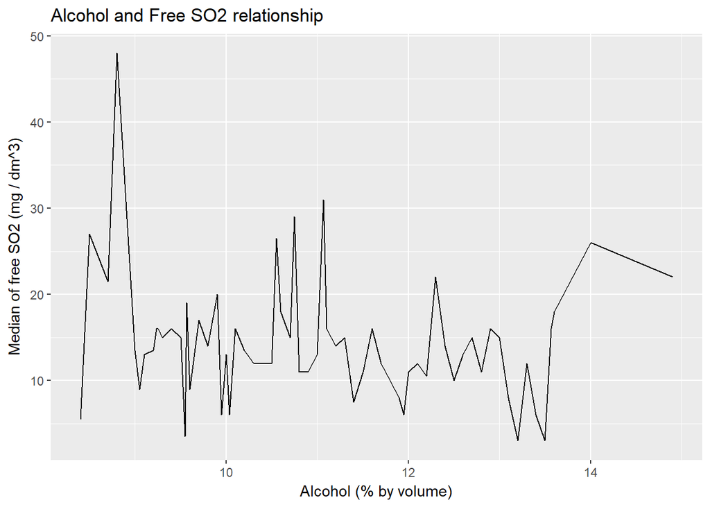

### Plot Three

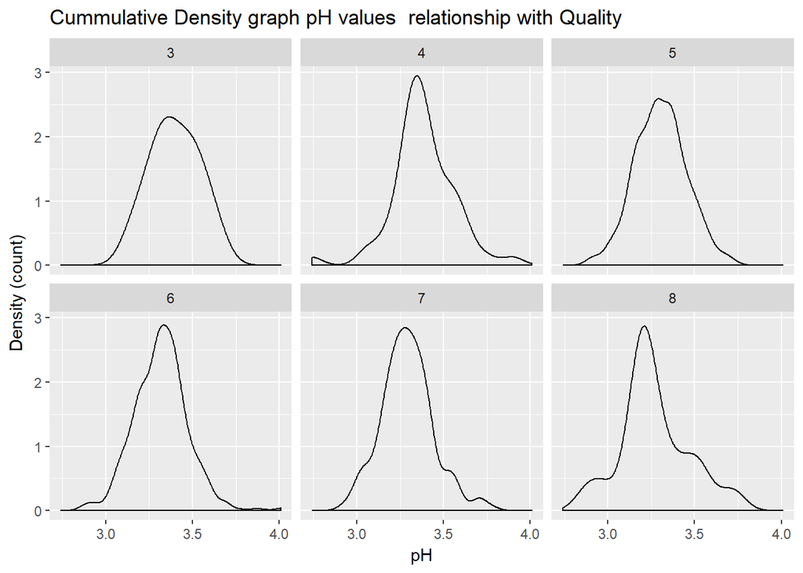

## From the above graphs the mean value of the pH seems to decrease with increase in rating. With that said, it is not necessary for wine to have lower pH to get higher rating, we can see a approximately normal curve in each of the rating.

# Reflection

Some of the learnings from the analysis were as follows:

It always seemed that pH value was a key factor in detemining the quality of the wines but from the analysis ,it seems that pH value do not exhibit any patterns which can be utilized as akey determinstic variable for wine quality testing by sensory analysis.

From the samples analyzed,the wines with higher Alcohol content exhibited lower SO2 content as compared with samples with lower Alcohol content.

For the buyer conscious of the sugar content in the wines, as we have seen spikes in the residual sugar for certain ranges of the Free and Total SO2.

A limitation of the current analysis is that the current data consists of samples collected from a specific portugal region. It will be intresting to obtain datasets across various wine making regions to eliminate any bias created by any secific qualities of the product.

During all my analysis toughest part was to pin point he factors that would influence the quality or play a major role in quality of wine. I also had to struggle hard to find out if there is any correlation between the factors I was finding interesting that could be influencing the quality of the wine.